# Exploratory Analysis of Flights Data

## Investigation Overview

> The dataset considered is year 2008. It consist of 2389217 records and 29 features. Here are the definitions of the features:

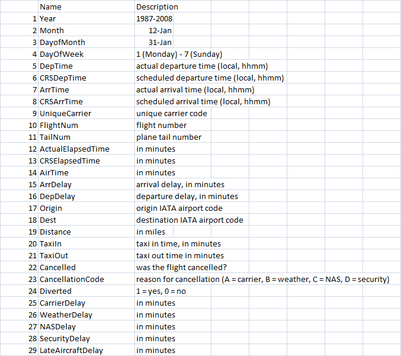

```python
# import all packages and set plots to be embedded inline
import numpy as np
import pandas as pd
import matplotlib.pyplot as plt
import seaborn as sb

%matplotlib inline

# suppress warnings from final output
import warnings
warnings.simplefilter("ignore")
```

```python
# load in the dataset into a pandas dataframe
df = pd.read_csv("2008.csv")
df_airports = pd.read_csv("airports.csv")
```

```python
# Dimension of the dataframe
df.shape
```

```
(2389217, 29)
```

```python
# Merge 2008 data with airports data
df = pd.merge(df, df_airports, left_on='Origin', right_on='iata')


# Function that select only positive values DepDelay and ArrDelay
def year(dataframe):
    data = dataframe.loc[(dataframe["DepDelay"]>=0) & (dataframe["ArrDelay"]>=0)]
    return data

df_08 = year(df)
df_08.head()
```

|  | Year | Month | DayofMonth | DayOfWeek | DepTime | CRSDepTime | ArrTime | CRSArrTime | UniqueCarrier | FlightNum | ... | NASDelay | SecurityDelay | LateAircraftDelay | iata | airport | city | state | country | lat | long |
| --- | --- | --- | --- | --- | --- | --- | --- | --- | --- | --- | --- | --- | --- | --- | --- | --- | --- | --- | --- | --- | --- |
| 0 | 2008 | 1 | 3 | 4 | 1343.0 | 1325 | 1451.0 | 1435 | WN | 588 | ... | 0.0 | 0.0 | 0.0 | HOU | William P Hobby | Houston | TX | USA | 29.645419 | -95.278889 |
| 1 | 2008 | 1 | 3 | 4 | 1125.0 | 1120 | 1247.0 | 1245 | WN | 1343 | ... | NaN | NaN | NaN | HOU | William P Hobby | Houston | TX | USA | 29.645419 | -95.278889 |
| 4 | 2008 | 1 | 3 | 4 | 1423.0 | 1400 | 1726.0 | 1710 | WN | 25 | ... | 0.0 | 0.0 | 0.0 | HOU | William P Hobby | Houston | TX | USA | 29.645419 | -95.278889 |
| 5 | 2008 | 1 | 3 | 4 | 2024.0 | 2020 | 2325.0 | 2325 | WN | 51 | ... | NaN | NaN | NaN | HOU | William P Hobby | Houston | TX | USA | 29.645419 | -95.278889 |
| 6 | 2008 | 1 | 3 | 4 | 1753.0 | 1745 | 2053.0 | 2050 | WN | 940 | ... | NaN | NaN | NaN | HOU | William P Hobby | Houston | TX | USA | 29.645419 | -95.278889 |

5 rows × 36 columns

```python
# Selecting specific variables that would be used in the analysis
dfn = df_08[["Month","DayofMonth", "state","airport", "Dest","UniqueCarrier","Distance","ArrDelay","DepDelay","CarrierDelay","WeatherDelay","NASDelay","SecurityDelay"]]
dfn = dfn.reset_index(drop=True)
dfn.head()
```

|  | Month | DayofMonth | state | airport | Dest | UniqueCarrier | Distance | ArrDelay | DepDelay | CarrierDelay | WeatherDelay | NASDelay | SecurityDelay |
| --- | --- | --- | --- | --- | --- | --- | --- | --- | --- | --- | --- | --- | --- |
| 0 | 1 | 3 | TX | William P Hobby | LIT | WN | 393 | 16.0 | 18.0 | 16.0 | 0.0 | 0.0 | 0.0 |
| 1 | 1 | 3 | TX | William P Hobby | MAF | WN | 441 | 2.0 | 5.0 | NaN | NaN | NaN | NaN |
| 2 | 1 | 3 | TX | William P Hobby | MCO | WN | 848 | 16.0 | 23.0 | 16.0 | 0.0 | 0.0 | 0.0 |
| 3 | 1 | 3 | TX | William P Hobby | MCO | WN | 848 | 0.0 | 4.0 | NaN | NaN | NaN | NaN |
| 4 | 1 | 3 | TX | William P Hobby | MCO | WN | 848 | 3.0 | 8.0 | NaN | NaN | NaN | NaN |

```python
# The dimension after removing the negative values
dfn.shape
```

```
(870780, 13)
```

### What are the main features of interest in your dataset?

> The main features considered are the ones that relate to delays, time, location and carriers.

## Univariate Exploration

> In this section, each variable is investigated to understand their distributions using univariate exploration

### How are the Departure and Arrival Delays distributed?

```python
# function for labelling
def chart_label(x_label,y_label,chart_title):
    plt.xlabel(x_label)
    plt.ylabel(y_label)
    plt.title(chart_title)
```

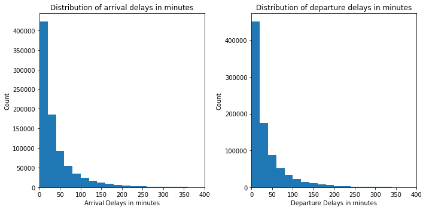

```python
# Using histogram to show the distribution of arrival delays
plt.figure(figsize=(10,5))
plt.subplot(1,2,1)
bin_arr = np.arange(0, df.ArrDelay.max()+20, 20)
plt.hist(data=dfn, x="ArrDelay", bins=bin_arr)
chart_label("Arrival Delays in minutes","Count","Distribution of arrival delays in minutes")
plt.xlim(dfn.ArrDelay.min(), 400)
#plt.ylim(0, 1000)

# Using histogram to show the distribution of departure delays
plt.subplot(1, 2, 2)
bin_dep = np.arange(0, df.DepDelay.max()+20, 20)
plt.hist(data=dfn, x="DepDelay", bins=bin_dep)
chart_label("Departure Delays in minutes","Count","Distribution of departure delays in minutes")
plt.xlim(dfn.DepDelay.min(), 400)
#plt.ylim(0, 1000)
plt.tight_layout()
```

> Both arrival and departure delays are skewed to the right which is expected because negative values have been removed which represent no delays. With time between 0 and 50 minutes having the highest frequency. It seems there more arrival delays between 300 and 400 minutes than departure delays in that same time range.

### How are flights distributed among the airlines?

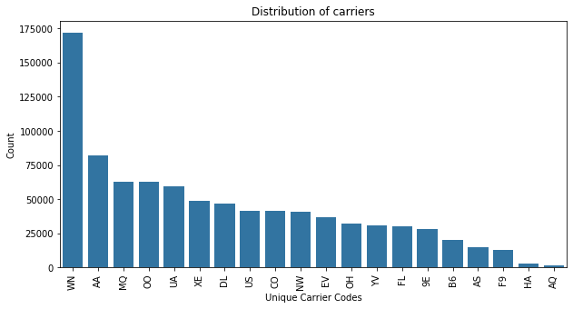

```python
plt.figure(figsize=(10,5))
base_color = sb.color_palette()[0]
orders = dfn.UniqueCarrier.value_counts()

sb.countplot(data=dfn, x="UniqueCarrier", color=base_color, order=orders.index)
plt.xticks(rotation=90)
chart_label("Unique Carrier Codes","Count","Distribution of carriers")
```

> **Southwest Airlines Co(WN)** had the most count followed by **Associated Aviation Act(AA)** while the least counts were **Hawaiian Airlines Inc(HA)** and **Aloha Airlines Inc(AQ)**

### What is the range of distance covered?

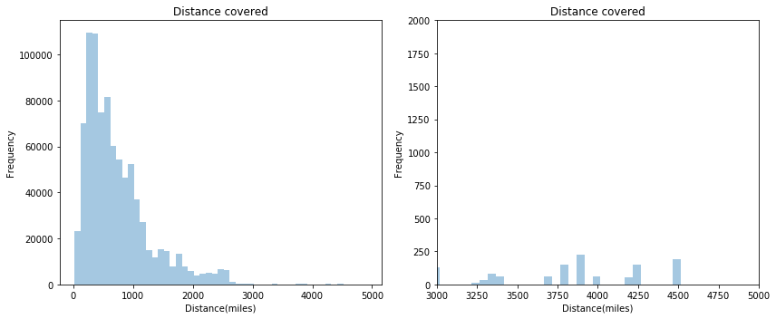

```python
# Histogram of the Distance
plt.figure(figsize= (12,5))
plt.subplot(1,2,1)
bins_distance = np.arange(17, dfn["Distance"].max()+20, 100)
sb.distplot(dfn["Distance"], kde=False, bins=bins_distance, color=base_color)
plt.title("Distance covered")
plt.xlabel("Distance(miles)")
plt.ylabel("Frequency");

# Zooming-in on the distance
plt.subplot(1,2,2)
bins_distance = np.arange(17, dfn["Distance"].max()+5, 50)
sb.distplot(dfn["Distance"], kde=False, bins=bins_distance)
plt.xlim(3000,5000)
plt.ylim(0, 2000)
plt.title("Distance covered")
plt.xlabel("Distance(miles)")
plt.ylabel("Frequency")

plt.tight_layout()
```

> The farthest distance is between 4000 to 5000 miles while most covered distances are less than 1500 miles.

### How are the Carriers, Weather, National Aviation System and Security Delays distributed?

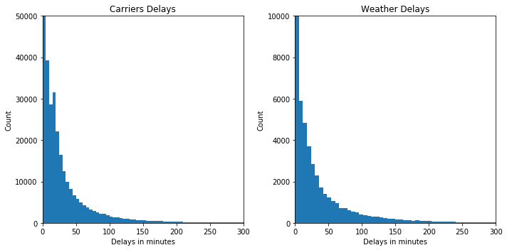

```python
# Looking at Carrier delays in minutes
plt.figure(figsize=(10,5))
plt.subplot(1,2,1)
bin_edges = np.arange(0, dfn["CarrierDelay"].max()+5, 5)
plt.hist(data=dfn, x="CarrierDelay", bins=bin_edges)
chart_label("Delays in minutes","Count","Carriers Delays")
plt.xlim(0, 300)
plt.ylim(0,50000)

## Looking at Weather delays in minutes
plt.subplot(1,2,2)
bin_edges = np.arange(0, dfn["WeatherDelay"].max()+2, 6)
plt.hist(data=dfn, x="WeatherDelay", bins=bin_edges)
chart_label("Delays in minutes","Count","Weather Delays")
plt.xlim(0, 300)
plt.ylim(0,10000)
plt.tight_layout()
```

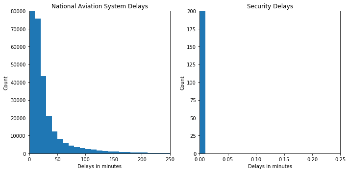

```python
# Distribution of National Aviation Delays

plt.figure(figsize=(10,5))
plt.subplot(1,2,1)
bin_edges = np.arange(0, dfn["NASDelay"].max()+2, 10)
plt.hist(data=dfn, x="NASDelay", bins=bin_edges)
chart_label("Delays in minutes","Count","National Aviation System Delays")
plt.xlim(0, 250)
plt.ylim(0, 80000)

# Distribution of Security Delays
plt.subplot(1,2,2)
bin_edges = np.arange(0, dfn["SecurityDelay"].max()+0.1, 1/100)
plt.hist(data=dfn, x="SecurityDelay", bins=bin_edges)
chart_label("Delays in minutes","Count","Security Delays")
plt.xlim(0, 0.25)
plt.ylim(0, 200)

plt.tight_layout()
```

> Most common delays for NAS is within 10 minutes and the least common is within 3 hours. Security delays is very small which simply seems non-existence.

> Comparing all the delays, Carrier and Weather delays seems to have more within an hour.

## Bivariate Exploration

> The bivariate exploration will be looking at:
> - How each state are affected on average by both arrival and departure delays?
> - How does distance contributes to delays?
> - How do Carriers(unique airlines) relate with arrival and departure delays?

### How are States affected by Arrival and Departure Delays?

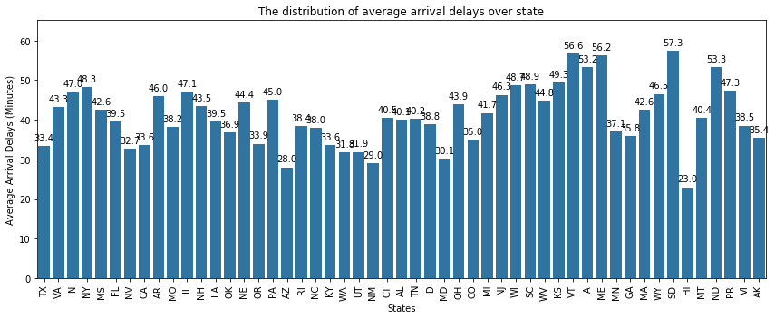

```python
plt.figure(figsize=(12,5))
bar_plot = sb.barplot(data=dfn, x="state", y="ArrDelay", errwidth=0, color=base_color)

### explanatory data

for p in bar_plot.patches:
    bar_plot.annotate(format(p.get_height(), '.1f'),
                   (p.get_x() + p.get_width() / 2., p.get_height()),
                   ha = 'center', va = 'center',
                   xytext = (0, 9),
                   textcoords = 'offset points')

chart_label("States","Average Arrival Delays (Minutes)","The distribution of average arrival delays over state")
plt.xticks(rotation=90)
plt.tight_layout();
```

> Working with the assumption that the level of uncertainty for the mean of each state is uniformly distributed, **Hawaii(HI)** has the lowest arrival delays while **South Dakota(SD)** have the highest arrival delays.

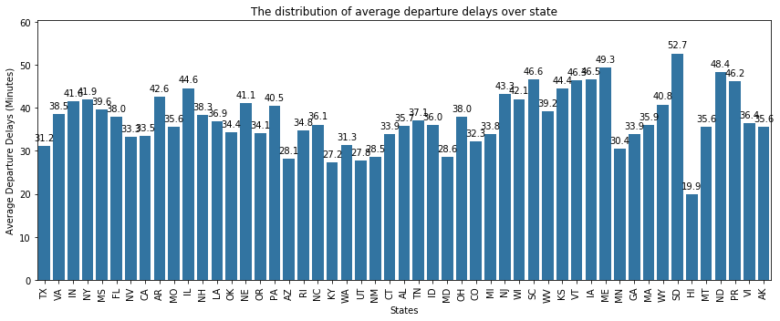

```python
### Departure delay

plt.figure(figsize=(12,8))

base_color = sb.color_palette()[0]
plt.figure(figsize=(12,5))
bar_plot = sb.barplot(data=dfn, x="state", y="DepDelay", errwidth=0, color=base_color)

### explanatory data

for p in bar_plot.patches:
    bar_plot.annotate(format(p.get_height(), '.1f'),
                   (p.get_x() + p.get_width() / 2., p.get_height()),
                   ha = 'center', va = 'center',
                   xytext = (0, 9),
                   textcoords = 'offset points')
chart_label("States","Average Departure Delays (Minutes)","The distribution of average departure delays over state")
plt.xticks(rotation=90)
plt.tight_layout();
```

> Once again, we see Hawaii(HI) having lowest average departure delay while South Dakota(SD) having the highest.

### How does distance contributes to delays?

```python
### The numbers of flights and mean of arrival and departure delays
num_delays = dfn.groupby(["state","Distance"]).agg({"ArrDelay": ["count","mean"],"DepDelay":"mean"})
num_delays.columns = ['Num_Flights','Mean_ArrDelay', 'Mean_DepDelay']
num_delays = num_delays.reset_index()
num_delays
```

|  | state | Distance | Num_Flights | Mean_ArrDelay | Mean_DepDelay |
| --- | --- | --- | --- | --- | --- |
| 0 | AK | 31 | 69 | 40.623188 | 41.826087 |
| 1 | AK | 71 | 2 | 20.000000 | 20.500000 |
| 2 | AK | 82 | 73 | 39.671233 | 36.917808 |
| 3 | AK | 95 | 156 | 42.006410 | 41.173077 |
| 4 | AK | 123 | 87 | 43.517241 | 45.183908 |
| ... | ... | ... | ... | ... | ... |
| 4302 | WY | 784 | 3 | 117.333333 | 105.666667 |
| 4303 | WY | 1046 | 28 | 53.642857 | 45.857143 |
| 4304 | WY | 1162 | 102 | 78.735294 | 70.362745 |
| 4305 | WY | 1386 | 4 | 49.750000 | 60.750000 |
| 4306 | WY | 1572 | 25 | 27.280000 | 19.960000 |

4307 rows × 5 columns

```python
num_delays[["Mean_ArrDelay","Mean_DepDelay"]].describe()
```

|  | Mean_ArrDelay | Mean_DepDelay |
| --- | --- | --- |
| count | 4307.000000 | 4307.000000 |
| mean | 39.009270 | 36.356183 |
| std | 18.767655 | 18.458172 |
| min | 0.000000 | 0.000000 |
| 25% | 28.546921 | 26.683826 |
| 50% | 35.733333 | 33.142857 |
| 75% | 45.993827 | 42.863682 |
| max | 506.000000 | 518.000000 |

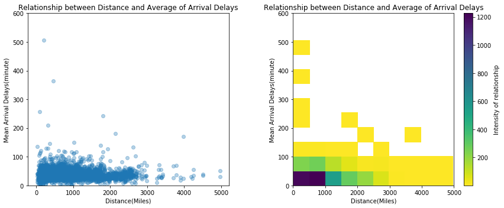

```python
# Distance with Arrival Delays

plt.figure(figsize=(12,5))
plt.subplot(1,2,1)
sb.regplot(data=num_delays, x="Distance", y="Mean_ArrDelay", fit_reg=False, x_jitter = 0.2, y_jitter = 0.2, scatter_kws = {'alpha' : 1/3})
plt.ylim(0, 600)
chart_label("Distance(Miles)","Mean Arrival Delays(minute)","Relationship between Distance and Average of Arrival Delays")

plt.subplot(1,2,2)
plt.hist2d(data = num_delays, x = 'Distance', y = 'Mean_ArrDelay', cmin=0.5, cmap="viridis_r")
plt.ylim(0, 600)
plt.xlim(0, 5000)
chart_label("Distance(Miles)","Mean Arrival Delays(minute)","Relationship between Distance and Average of Arrival Delays")
plt.colorbar(label="Intensity of relationship");

plt.tight_layout()
```

> The charts show that shorter distances experienced more arrival delays and the delays are intense within 100 minutes. Maybe, because shorter distances are more compare to long distances.

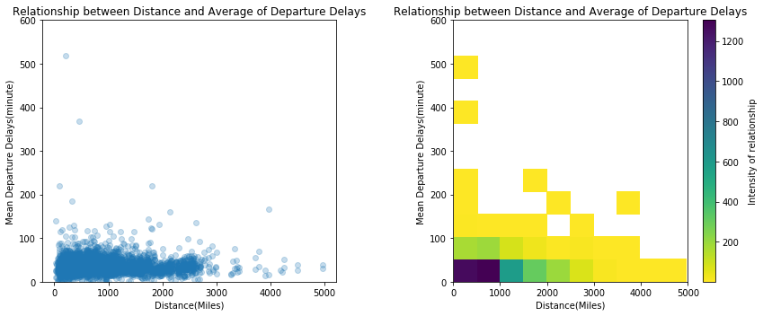

```python
# Departure Delays
plt.figure(figsize=(12,5))
plt.subplot(1,2,1)
sb.regplot(data=num_delays, x="Distance", y="Mean_DepDelay", fit_reg=False, x_jitter = 0.2, y_jitter = 0.2, scatter_kws = {'alpha' : 1/4})
plt.ylim(0, 600)
chart_label("Distance(Miles)","Mean Departure Delays(minute)","Relationship between Distance and Average of Departure Delays")

plt.subplot(1,2,2)
plt.hist2d(data = num_delays, x = 'Distance', y = 'Mean_DepDelay', cmin=0.5, cmap="viridis_r")
plt.ylim(0, 600)
plt.xlim(0, 5000)
chart_label("Distance(Miles)","Mean Departure Delays(minute)","Relationship between Distance and Average of Departure Delays")
plt.colorbar(label="Intensity of relationship");

plt.tight_layout()
```

> The chart shows similar characteristics with the arrival delays and distance. In addition, departure delays has a more between 100 and 250 minutes.

### How do carriers(unique airlines) relate with arrival and departure delays?

```python
# group the carriers with arrival delays and departure delays time in hours
df1 = dfn[["state","UniqueCarrier","ArrDelay","DepDelay"]]
df_melt = pd.melt(df1, id_vars=['UniqueCarrier', 'ArrDelay','DepDelay'])
df_melt.head()
```

|  | UniqueCarrier | ArrDelay | DepDelay | variable | value |
| --- | --- | --- | --- | --- | --- |
| 0 | WN | 16.0 | 18.0 | state | TX |
| 1 | WN | 2.0 | 5.0 | state | TX |
| 2 | WN | 16.0 | 23.0 | state | TX |
| 3 | WN | 0.0 | 4.0 | state | TX |
| 4 | WN | 3.0 | 8.0 | state | TX |

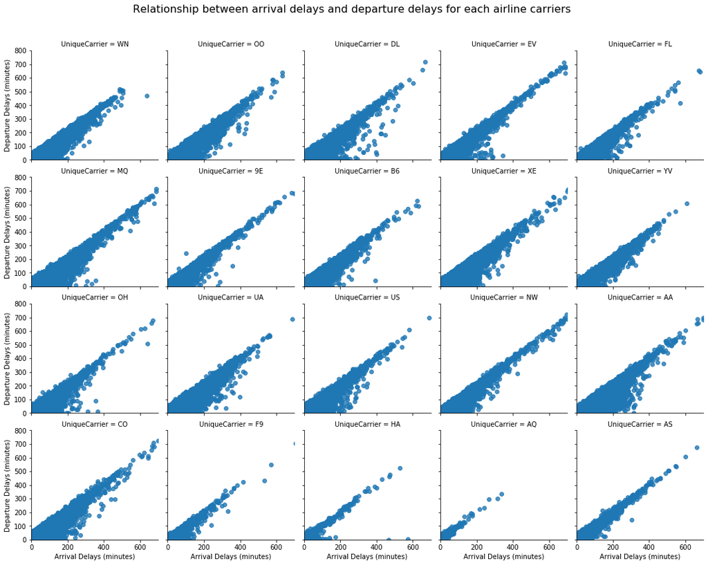

```python
#plt.scatter(data=dfn_carrier, x="Mean_ArrDelay", y="Mean_DepDelay")
g = sb.FacetGrid(data = df_melt, col = 'UniqueCarrier',col_wrap=5)
g.map(sb.regplot, "ArrDelay","DepDelay",  fit_reg=False)
g.set(xlim=(0,700))
g.set(ylim=(0,800))
g.set_ylabels("Departure Delays (minutes)")
g.set_xlabels("Arrival Delays (minutes)")
plt.subplots_adjust(top=0.9)
g.fig.suptitle("Relationship between arrival delays and departure delays for each airline carriers", fontsize=16)
```

> Though the figure above is a multivariate exploration of air carriers with the relationship with arrival and departure delays, it actually used to compare the bivariate characteristics of arrival and departure delays for each air carrier.

> The charts show that generally departure delays are directly proportional to arrival delays for the carriers. This means that the more departure delays the more the arrival delays. Could this relationship be said to be consistent with the states?

## Multivariate Exploration

> Here, we will try to build on that relationship between departure and arrival delays with Carriers by answering the question:
> - How does this observed relationship between carriers and delays affect origin or destination of flights?

```python
# Taking a sample of 300 from the dataset
sample = np.random.choice(dfn.shape[0], 300, replace=False)
dfn_sample = dfn.loc[sample]
```

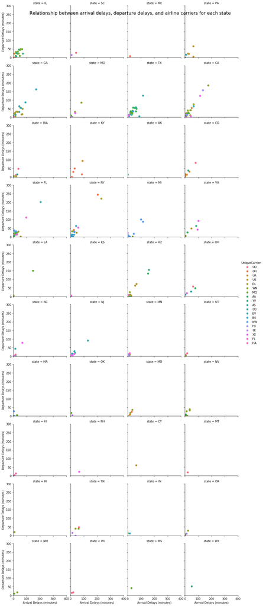

```python
# show state, carriers and Arrival and Departure delays
plt.figure(figsize=(12,5))
g = sb.FacetGrid(data = dfn_sample, col = "state", hue="UniqueCarrier", margin_titles=True, height=3, col_wrap=4)
g.map(plt.scatter, "ArrDelay", "DepDelay")
g.set(xlim=(0,400))
g.set(ylim=(0,300))
g.add_legend()
g.set_ylabels("Departure Delays (minutes)")
g.set_xlabels("Arrival Delays (minutes)")
g.fig.suptitle("Relationship between arrival delays, departure delays, and airline carriers for each state", fontsize=16);
```

> A random sample of 300 was drawn from the dataset to make the above multivariate analysis of departure delays against arrival delays and how it affect each state and airline carriers.